# Task 3: Text wrangling and analysis

Pol Carbó Mestre

March 9, 2022

```r
knitr::opts_chunk$set(echo = TRUE, message = F, warning = F)
```

```r
library(tidyverse)
library(tidytext)
library(textdata)
library(pdftools)
library(ggwordcloud)
library(ggtext)
```

# Overview

This task will perform a text wrangling and analysis of The little prince book by Antoine de Saint-Exupéry. The story addresses themes of loneliness, friendship, love, and loss. The analysis aims to evaluate those themes by assessing the most common words used in the book and their emotional connotation.

**References:**  
- Antoine de Saint-Exupery. The Little Prince. Bomoo ebook english series (2003).  
- NRC lexicon: https://saifmohammad.com/WebPages/NRC-Emotion-Lexicon.html  
- AFINN lexicon: https://emilhvitfeldt.github.io/textdata/reference/lexicon_afinn.html

# Text Import and data wrangling

The first step is to read the pdf containing the book.

```r
the_little_prince_text <- pdf_text(here::here('data', 'the_little_prince.pdf'))
```

Once we have created the object with all book’s contents, we will transform it into a data frame and arrange it by chapters (the text unit used in this analysis).

```r
# Transforming to a data frame
the_little_prince_lines <- data.frame(the_little_prince_text) %>%
  mutate(page = 1:n()) %>%
  mutate(text_full = str_split(the_little_prince_text, pattern = '\\n')) %>%
  unnest(text_full) %>%
  mutate(text_full = str_trim(text_full))

# Add a new column that contains the Chapter number
the_little_prince_chapts <- the_little_prince_lines %>%
  slice(-(1:197)) %>% # Chapter 1 starts at line 198
  mutate(chapter = ifelse(str_detect(text_full, "Chapter"), text_full, NA)) %>%
  fill(chapter, .direction = 'down') %>%
  separate(col = chapter, into = c("ch", "no"), sep = " ") %>%
  mutate(chapter = as.numeric(as.roman(no)))
```

# Most frequently used words

Before getting some word counts by chapter, we will remove stop words. These are common but uninteresting words such as “a”, “the”, “and” that are not relevant, since do not provide meaning for the analysis.

```r
the_little_prince_words <- the_little_prince_chapts %>%
  unnest_tokens(word, text_full) %>%
  select(-the_little_prince_text)

the_little_prince_words_clean <- the_little_prince_words %>%
  anti_join(stop_words, by = 'word')
```

Once we have removed those words, we can evaluate their presence.

```r
nonstop_counts <- the_little_prince_words_clean %>%
  count(chapter, word)
```

In the following plot, we represent the five words per chapter.

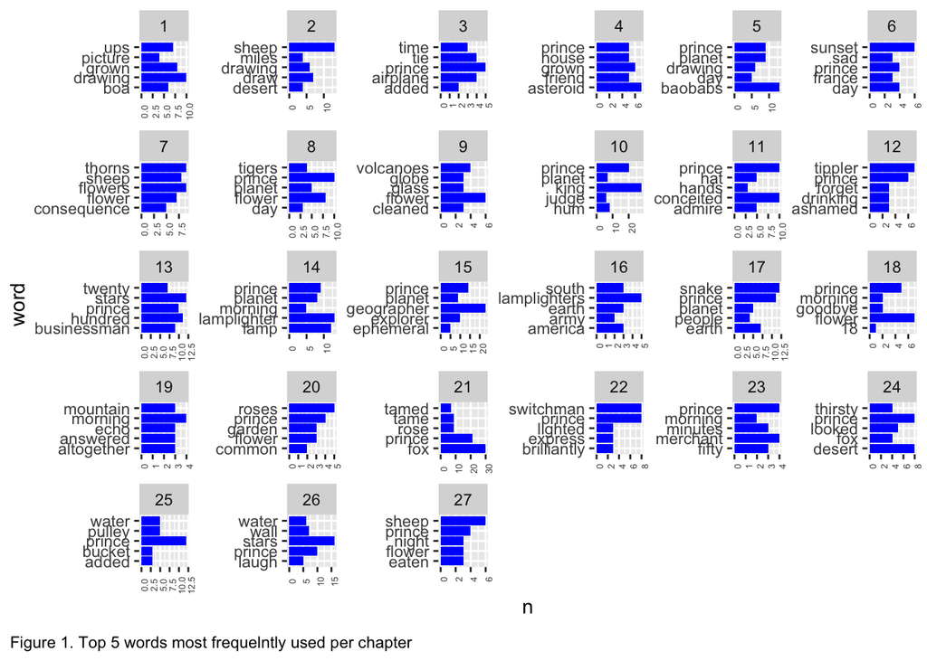

```r
# Find the top 5 words from each chapter
top_5_words <- nonstop_counts %>%
  group_by(chapter) %>%
  arrange(-n) %>%
  slice(1:5) %>%
  ungroup()

# Representation
ggplot(data = top_5_words, aes(x = n, y = word)) +
  geom_col(fill = "blue") +
  facet_wrap(~chapter, scales = "free") +
  theme(axis.text.x = element_text(size = 5, angle=90),
        plot.caption = element_textbox_simple(margin = margin(10,0,0,0)),
        plot.caption.position = "plot") +
  labs(caption = 'Figure 1. Top 5 words most frequelntly used per chapter')
```

We could also evaluate the most common words for the entire book— a helpful way to represent it is through a Word cloud.

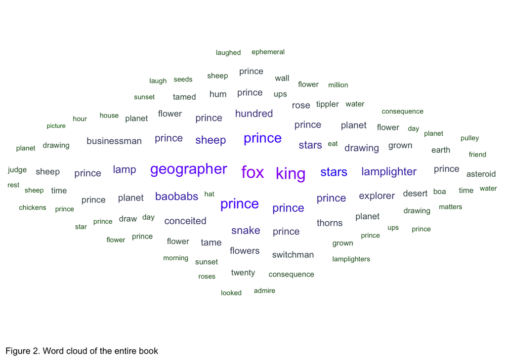

```r
book_top100 <- nonstop_counts %>%
  arrange(-n) %>%
  slice(1:100)

# Representation
ggplot(data = book_top100, aes(label = word)) +
  geom_text_wordcloud(aes(color = n, size = n), shape = "diamond") +
  scale_size_area(max_size = 6) +
  scale_color_gradientn(colors = c("darkgreen","blue","purple")) +
  theme_minimal() +
  labs(caption = 'Figure 2. Word cloud of the entire book') +
  theme(plot.caption = element_textbox_simple(margin = margin(10,0,0,0)),
        plot.caption.position = "plot")
```

# Sentiment analysis

Finally, we can evaluate how sentiments change throughout the book. To do so, we can bind the words on the book with lexicon sources associating words to emotions.

## Afinn score by chapter:

One of these lexicon sources is AFINN which assigns words with a score that runs between -5 and 5, with negative scores indicating negative sentiment and positive scores indicating positive sentiment.

First, we have to bind our words to the AFINN lexicon.

```r
# bind words in `the_little_prince_nonstop_words` to `afinn` lexicon:
the_little_prince_afinn <- the_little_prince_words_clean %>%
  inner_join(get_sentiments("afinn"), by = 'word')
```

With the merged data sets, we could represent the counts of words by sentiment ranking for each chapter. However, it is easier to evaluate the emotional evolution of the book by visualizing the mean AFINN score by chapter.

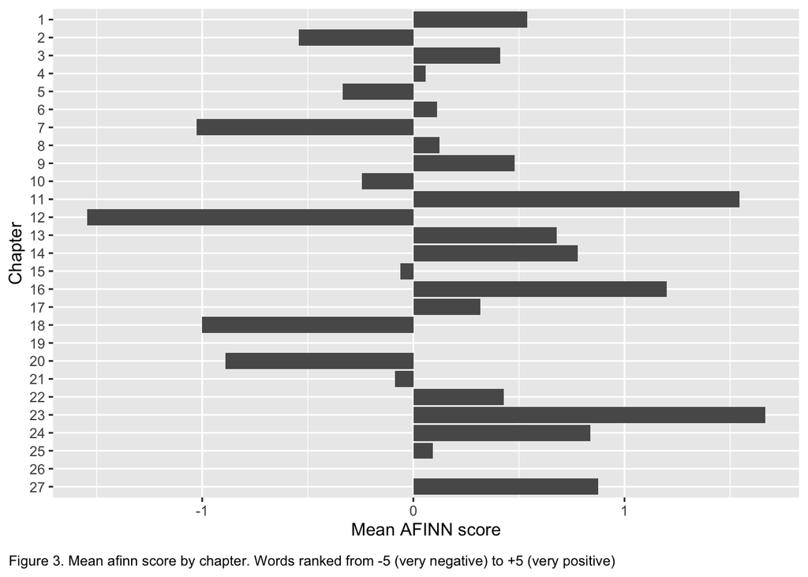

```r
# Find the mean afinn score by chapter:
afinn_means <- the_little_prince_afinn %>%
  group_by(chapter) %>%
  summarize(mean_afinn = mean(value))
# Representation
ggplot(data = afinn_means,
       aes(x = fct_rev(factor(chapter)),
           y = mean_afinn)) +
           # y = fct_rev(as.factor(chapter)))) +
  geom_col() +
  coord_flip() +
  labs(y = "Mean AFINN score",
       x = "Chapter",
       caption = 'Figure 3. Mean afinn score by chapter. Words ranked from -5 (very negative) to +5 (very positive)') +
  theme(plot.caption = element_textbox_simple(margin = margin(10,0,0,0)),
        plot.caption.position = "plot")
```

## Emotions by chapter with NRC lexicon

This lexicon includes bins for eight emotions (anger, anticipation, disgust, fear, joy, sadness, surprise, trust) and positive/negative.

As we did before, we first bind our words to the NRC lexicon to evaluate the count of these emotions per chapter.

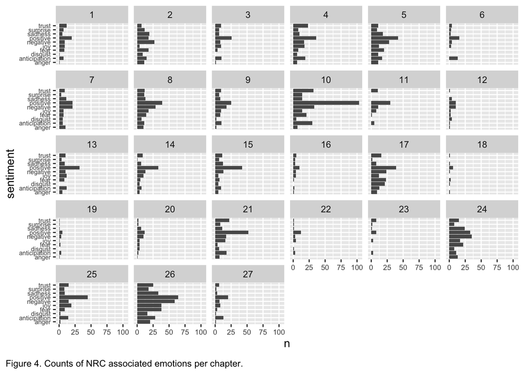

```r
# bind our the_little_prince data to the NRC lexicon
the_little_prince_nrc <- the_little_prince_words_clean %>%
  inner_join(get_sentiments("nrc"))

# find the count of words by chapter and sentiment bin
the_little_prince_nrc_counts <- the_little_prince_nrc %>%
  count(chapter, sentiment)

# Representation
ggplot(data = the_little_prince_nrc_counts, aes(x = sentiment, y = n)) +
  geom_col() +
  facet_wrap(~chapter) +
  coord_flip() +
  labs(caption = 'Figure 4. Counts of NRC associated emotions per chapter.')+
  theme(axis.text.x = element_text(size = 7),
        axis.text.y = element_text(size = 6),
        plot.caption = element_textbox_simple(margin = margin(10,0,0,0)),
        plot.caption.position = "plot")
```